# Part II - (Analysis Slide Deck )

## by (Adegun Ahmed Olamilekan)

## Investigation Overview

The objective of this slide is to provide insight to the dataset analysed. the dataset was exposed to exploratory data analysis, which appraised the major vaiables required to investigated and highlight the summary of findings as below;

[output not shown]

## Dataset Overview

The dataset for this analysis id Loan Dataset from Proper. This data set contains 113,937 loans with 81 variables on each loan, including loan amount, borrower rate (or interest rate), current loan status, borrower income, and many others.

#### Employment Status of Borrower employed

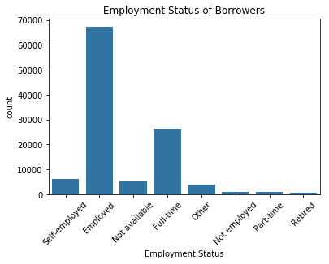

#### Relationship between BorrowerAPR and BorrowerRate

There is a strong relationship between Borrower Annual Percentage Rate and Borrower Rate. The implication of this is that, the higher the borrower rate the higher the borrower annual rate.

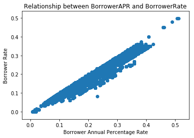

#### Which state borrow more with Term of Loan

Califonia is the state that subscribe to most amount of loan. Also, from the analysis, borrower prefer loan of 36months repayment term over 60months, while 12months term is the least popular

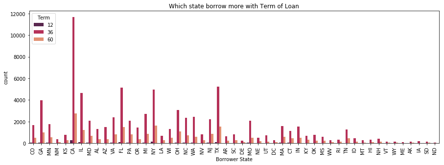

#### Borrower Rate based on Employment Status

The barplot below shows how the borrowing rate accrued to the loan affect the employment status of the borrower. borrower that are not employed tend to pay more rate across all term, However, consideration might have been given to retired borrowers over short term loan payable within 12months as they enjoyed a loq rate of interest on the loan. They pay roughly 6% in rate while others pay more than 11% for 12months term of loan period.

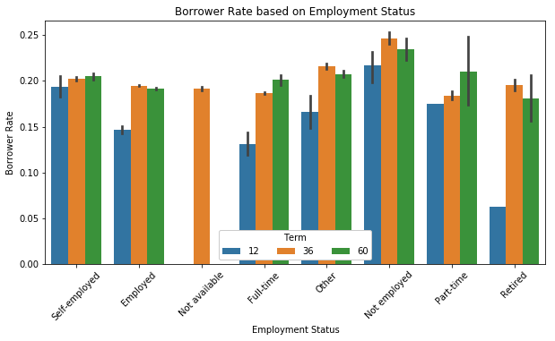

#### Borrower Rate based on Employment Status

This graph futher illustrate the analysis that borrower that are not employed pay more rate and retired borrowers pay the least in rate for 12months loans.

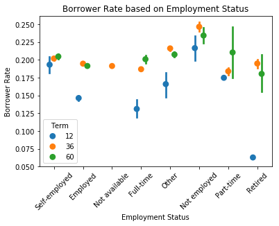

#### Relationship among Numerical Variables

The below shows that Monthly loan payment is heavy dependent on the loan original amount, however, stated montly income of borrowers is not significant in determing borrower monthly loan payment, borrower rate, borrower APR and lender yield.

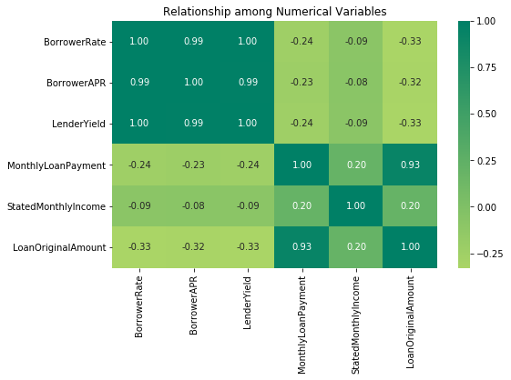